# FordGoBike Exploration

#### Duration vs Start Day

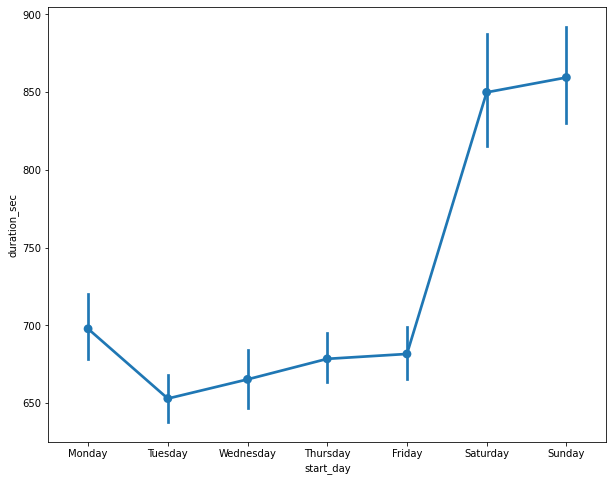

```python
plt.figure(figsize = (10,8))
sb.pointplot(data = ford_clean, x = 'start_day', y = 'duration_sec', order = ['Monday', 'Tuesday', 'Wednesday', 'Thursday', 'Friday', 'Saturday', 'Sunday'], color=base_color)
```

Here we can see the average duration of cycling is highest on Mondays of all weekdays, but the overall cycling duration takes a very clear spike on weekends, increaing by more than 150 seconds on average.

#### Duration vs Start Hour

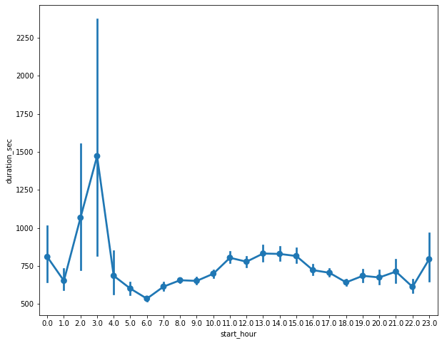

```python
plt.figure(figsize = (10,8))
sb.pointplot(data = ford_clean, x = 'start_hour', y = 'duration_sec', color=base_color)
```

As we can see from the graph, times of 2 and 3 in the morning seem to have the longest durations, though the error bars suggest that these may well be incorrect. What is interesting to note is the fact that the average duration is slightly lower around the rush hour times, and increaes during the day between these times, which again supports the thoery that a large proportion of our dataset ride to and from work, for a shorter time on average than those that do not use the bikes for this purpose.

Before moving on to the mulitvariate analysis, I would like to now look at the relationships between some of independent variable of interest.

### Relationship Between Independent Variables

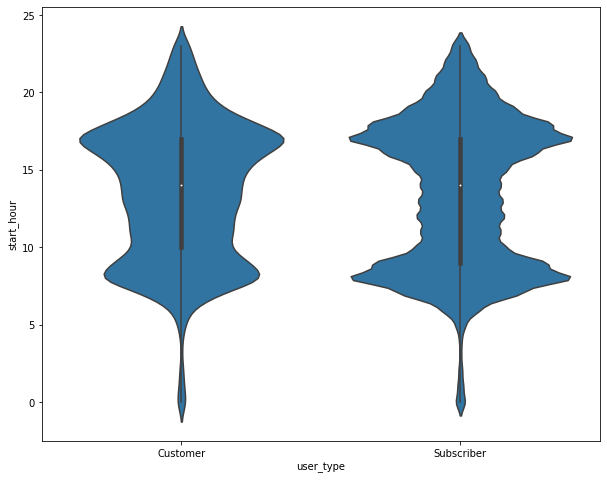

```python
plt.figure(figsize=(10,8))
base_color = sb.color_palette()[0]
sb.violinplot(data = ford_vlim, x = 'user_type', y = 'start_hour',
              color=base_color);
```

This violin plot seems to suggest that both subscribers and customers use the bikes most frequently during rush hour, so we can infer it is being used as a mode of transport for work, with the subscribers using it slightly more, in particular on the way to work in the mornings. Customers are also far more likely to use the bikes between work hours than subscribers.

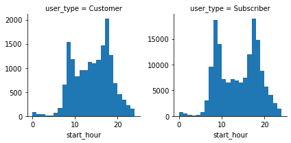

```python
bins = np.arange(0, 24+1, 1)
g = sb. FacetGrid(data =  ford_clean, col = 'user_type', sharey = False)
g.map(plt.hist, 'start_hour', bins = bins)
```

The faceted graph shows the above in more detail, and confrims that both subscribers and customers prefer to use the service during rush hour times, but that the proportion of subscribers using it is higher, and there is more evidence of what we saw in the violin plot above, that a higher proportion of customers use the bike service during the day, between work hours.

#### Start Hour vs Bike Share

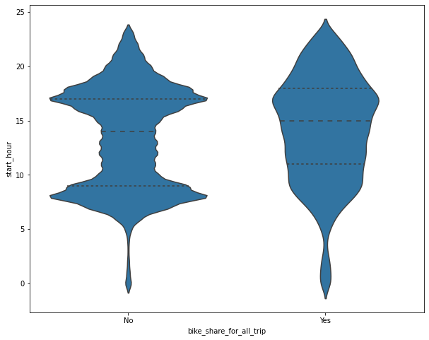

```python
plt.figure(figsize=(10,8))
base_color = sb.color_palette()[0]
sb.violinplot(data = ford_vlim, x = 'bike_share_for_all_trip', y = 'start_hour',
              color=base_color, inner='quartile');
# relevant in the sense that it shows a correlation between those who don't bike share and using the ford bike during work hours.
```

This is probably the plot with the biggest difference so far, showing that people who don't bike share for the whole trip follow the 'work' trip pattern, whilst the bike sharers don't, although they do still peak at the same time (approximately 17:00 pm).

#### User Count by Gender

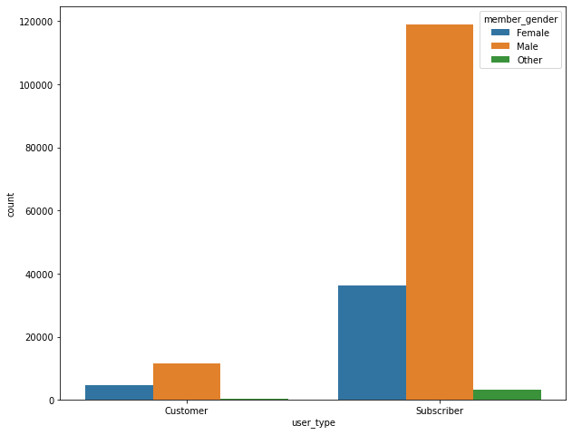

```python
plt.figure(figsize=(10,8))
sb.countplot(data = ford_clean, x = 'user_type', hue = 'member_gender')
# The ratio of male/female/is more or less the same amongst subscribers and customers.
```

A slightly higher proportion of men subscribe compared to women.

#### Bike Share vs User Type

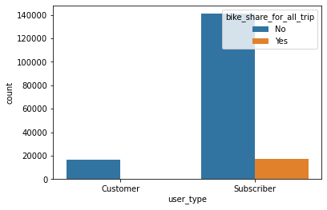

```python
sb.countplot(data = ford_clean, x = 'user_type', hue = 'bike_share_for_all_trip')
# Not sure if relevant overall, though it does show an interesting link: only subscribers bike share, which is opposite to what I thought as I thought it would be random customers choosing to share a bike
```

```python
ford_clean[ford_clean['user_type'] == 'Customer'].bike_share_for_all_trip.value_counts()
```

```
No     16553
Yes        0
Name: bike_share_for_all_trip, dtype: int64
```

This tells us that in fact, only subscribers bike share. Most likely it is an option only available to subscribers.

#### Start day by User Count

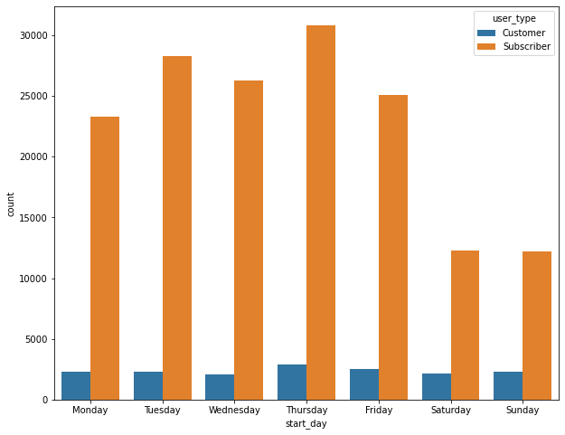

```python
plt.figure(figsize = (10,8))
sb.countplot(data = ford_clean, x = 'start_day', hue = 'user_type', order = ['Monday', 'Tuesday', 'Wednesday', 'Thursday', 'Friday', 'Saturday', 'Sunday'])
```

# Multivariate analysis

```python
# Creating a random sample of 500 to avoid overcrowding in plot
np.random.seed(2018)
sample = np.random.choice(ford_vlim.shape[0], 500, replace = False)
ford_clean_subset = ford_vlim.iloc[sample]
```

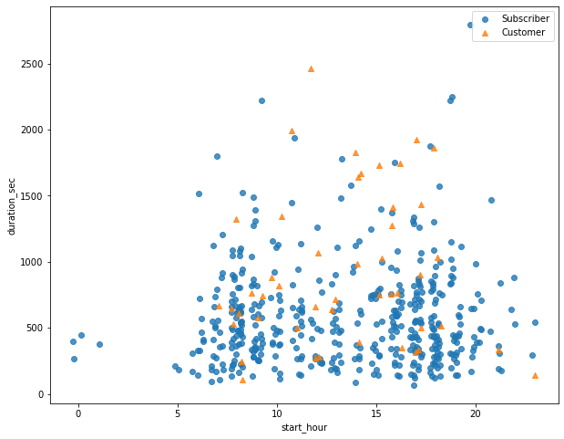

```python
# Graph for Duration vs Start Hour
plt.figure(figsize = (10,8))
ttype_markers = [['Subscriber', 'o'],
                 ['Customer', '^']]

for ttype, marker in ttype_markers:
    plot_data = ford_clean_subset.loc[ford_clean_subset['user_type']==ttype]
    sb.regplot(data = plot_data, x = 'start_hour', y = 'duration_sec',
          x_jitter = 0.3, fit_reg = False, marker = marker)
plt.legend(['Subscriber', 'Customer'])
```

We can see from this multivariate plot that the average position of customers is definitely higher than for subscribers, which cluster more around the 500 second mark

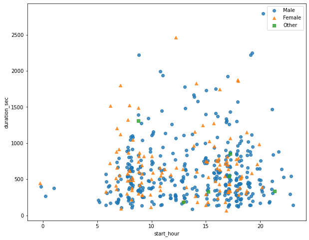

```python
# Create plot for duration vs start hour for given gender
plt.figure(figsize = (10,8))
ttype_markers = [['Male', 'o'],
                 ['Female', '^'],
                ['Other', 's']]

for ttype, marker in ttype_markers:
    plot_data = ford_clean_subset.loc[ford_clean_subset['member_gender']==ttype]
    sb.regplot(data = plot_data, x = 'start_hour', y = 'duration_sec',
          x_jitter = 0.3, fit_reg = False, marker = marker)
plt.legend(['Male', 'Female', 'Other'])
```

```python
# now we want to create another slightly larger random sample for a new exploration
np.random.seed(2018)
sample = np.random.choice(ford_vlim.shape[0], 1000, replace = False)
ford_clean_subset2 = ford_vlim.iloc[sample]
```

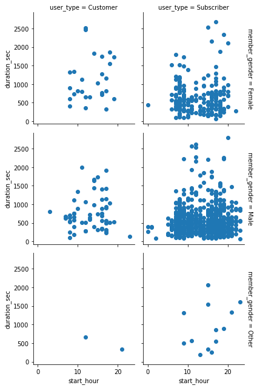

```python
# Creating faceted graphs for duration vs start hour for given user type and member genders.
plt.figure(figsize = (10,8))
g = sb.FacetGrid(data = ford_clean_subset2, col = 'user_type', row = 'member_gender',
                margin_titles = True)
g.map(plt.scatter, 'start_hour', 'duration_sec')
```

From the faceted graphs we can see a few things. For both males and female customers, the graphs are far less clustered towards the bottom than for subscribers, which shows why the average cycle duration is much higher for customers. We can also see despite the small data size, that the average duration appears to be slightly higher for females than males, regardless of whether or not they are users or subscribers.

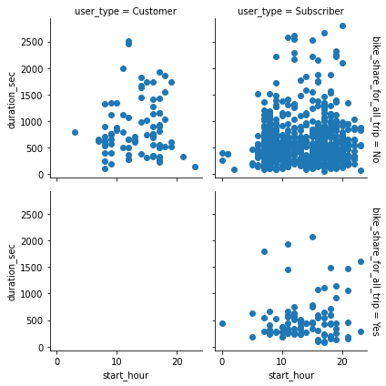

```python
# Creating faceted graphs for duration vs start hour for given user type and bike sharing status.
plt.figure(figsize = (10,8))
g = sb.FacetGrid(data = ford_clean_subset2, col = 'user_type', row = 'bike_share_for_all_trip',
                margin_titles = True)
g.map(plt.scatter, 'start_hour', 'duration_sec')
```

Seeing as we discovered before that all bike sharers are subscribers, we would expect the average duration for bike sharers to be similar to that of subscribers, but it ends up being similar to those who don't bike share. The reason, as we can see from the graph, looks mainly to be the two rush hour times which cause a major cluster below a duration of 1000 seconds on the subscriber vs non bike sharer graph. Comparing just the cycling duration of cutomers with the cycling duration for bike sharers, it would appear that the customer duration should be quite significanly higher on average to the eye, with many non bike sharers cycling longer than 1500 seconds as opposed to a handful for those that bike share, but of course, those rush hours values for subscribers affect the average value for those that don't bike share. Thanks to this graph we can make a more confident assertion that solo cyclists cycle longer than bike sharers, in particular outside rush hours.

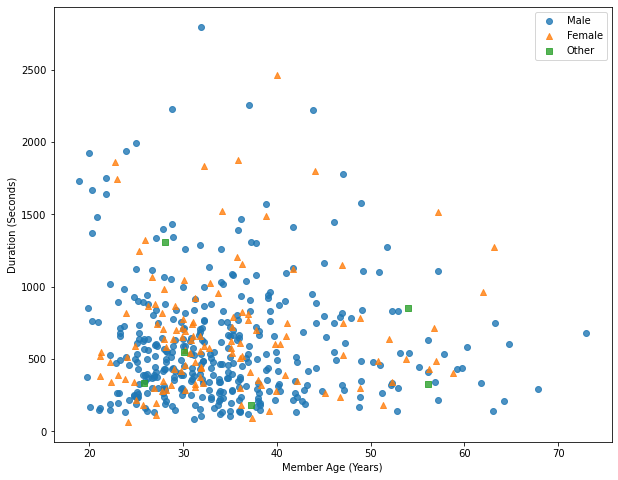

```python
# Creating a graph of duration vs member age for given genders
plt.figure(figsize = (10,8))
ttype_markers = [['Male', 'o'],
                 ['Female', '^'],
                ['Other', 's']]

for ttype, marker in ttype_markers:
    plot_data = ford_clean_subset.loc[ford_clean_subset['member_gender']==ttype]
    sb.regplot(data = plot_data, x = 'member_age', y = 'duration_sec',
          x_jitter = 0.3, fit_reg = False, marker = marker);
plt.xlabel('Member Age (Years)')
plt.ylabel('Duration (Seconds)')
plt.legend(['Male','Female','Other'])
```

We can see that the average duration seems to be slightly longer longer than that for males, although it isn't completely clear to see.

```python
# Again, creating a new sample for exploring.
np.random.seed(2018)
sample = np.random.choice(ford_vlim.shape[0], 250, replace = False)
ford_clean_subset3 = ford_vlim.iloc[sample]
```

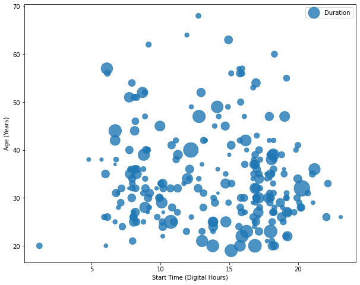

```python
# Plotting age vs start time with duration legend
plt.figure(figsize = (10,8))
sb.regplot(data = ford_clean_subset3, x = 'start_hour', y = 'member_age',
          x_jitter = 0.3, fit_reg = False,
               scatter_kws = {'s' : ford_clean_subset3['duration_sec']/4});
plt.xlabel('Start Time (Digital Hours)')
plt.ylabel('Age (Years)')
plt.legend(['Duration'])
```

We can see that for ages above 40, data is more sparse, so longer durations seem to make up a higher proportion than those below, which shows the average, again it seems, in part because of the lack of short durations which cluster during rush hours for under 40s.

### Talk about some of the relationships you observed in this part of the investigation. Were there features that strengthened each other in terms of looking at your feature(s) of interest?

From the faceted graph I saw that the duration for bike sharers compared to non-bike sharing customers was actually a lot more evident than it was just with non-bike sharers, as the effect of work travel on non bike sharing subscribers caused a reduction in the means calculated in the bivariate plot. The distribution of longer durations for customers also gave us a better understanding of that disparity in mean values calculated in the bivariate exploration, and it appears a higher proportion of people over 40 go on longer duration cycles, again in part due to the effect of lower duration cycles amongst young workers.